# R Essentials for Data Analysis

### 2.4.3 One-way ANOVA and Kruskal-Wallis test

Test birth weight against categorized values of gestation.

For this example, we will categorize the data based on the following criteria

- `< 37` weeks: pre-term
- `37-41` weeks: full-term
- `> 41` weeks: late term
1. Categorize the data. We will use the `cut()` function to create a factor from the current gestational age (in days)
   - The breaks are from 0 to `37 * 7`, `37 * 7` to `41 * 7`, and older than `41 * 7`
   - The labels set the labels for the factor
   - When `right` is set to FALSE, then the interval will be closed on the left (include the lower number) and open on the right (excludes the right number)

```r
library(dplyr)
bw_data <- bw_data %>%
  mutate(gestation_cat=cut(gestation,
                             breaks=c(0, 37*7, 41*7, Inf),
                             labels=c("pre term", "full term", "late term"),
                             right=F))
```

2. Run the ANOVA

```r
anova <- aov(bwt ~ gestation_cat, data=bw_data)
summary(anova)
```

```
##                 Df Sum Sq Mean Sq F value Pr(>F)
## gestation_cat    2  61546   30773   108.4 <2e-16 ***
## Residuals     1171 332512     284
## ---
## Signif. codes:  0 '***' 0.001 '**' 0.01 '*' 0.05 '.' 0.1 ' ' 1
```

Like the t-test and Wilcox test, one can save the results to a variable.  
In the case of ANOVA, save the output from summary

- The p-values for each term are saved in the column named “Pr(>F)”
- **NOTE**: The last item in the p-values is `NA` as it corresponds to the residuals.

```r
anova_result <- summary(anova)
anova_pvalues <- anova_result[[1]][["Pr(>F)"]]
anova_pvalues
```

```
## [1] 6.571396e-44           NA
```

3. Generate diagnostic plots for ANOVA

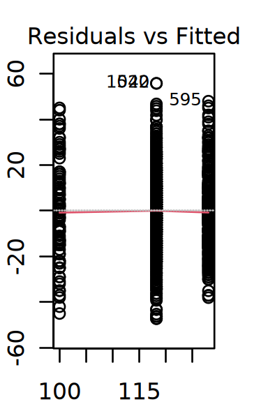

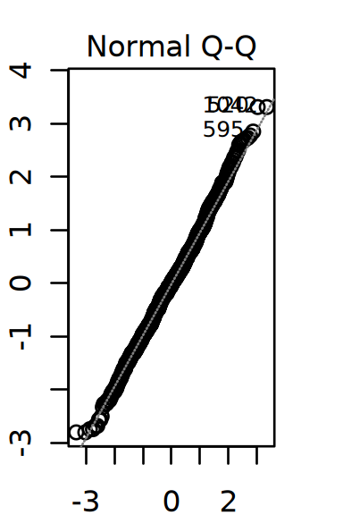

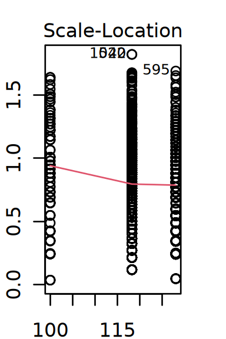

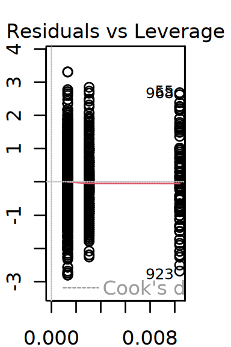

```r
plot(anova)
```

### 2.4.4 Kruskal-Wallis test

1. Run the Kruskal-Wallis test

```r
kruskal.test(bwt ~ gestation_cat, data=bw_data)
```

```
##
##  Kruskal-Wallis rank sum test
##
## data:  bwt by gestation_cat
## Kruskal-Wallis chi-squared = 146.76, df = 2, p-value < 2.2e-16
```

2. Create a box plot to visualize

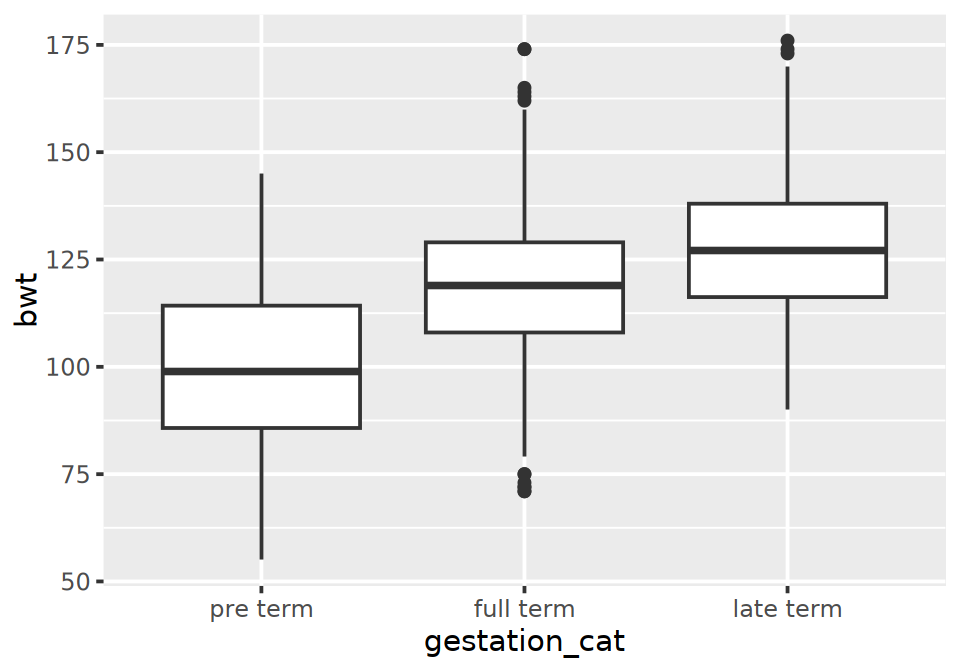

```r
ggplot(bw_data, aes(x=gestation_cat, y=bwt)) +
  geom_boxplot()
```

### 2.4.5 Two-way ANOVA

Compare birth weight to categorized gestation and smoking

1. Ensure that “smoking” is a factor (not character)

```r
bw_data$smoke <- factor(bw_data$smoke)
```

2. Run without interaction

```r
summary(aov(bwt ~ gestation_cat + smoke, data=bw_data))
```

```
##                 Df Sum Sq Mean Sq F value Pr(>F)
## gestation_cat    2  61546   30773  114.97 <2e-16 ***
## smoke            1  19338   19338   72.25 <2e-16 ***
## Residuals     1170 313174     268
## ---
## Signif. codes:  0 '***' 0.001 '**' 0.01 '*' 0.05 '.' 0.1 ' ' 1
```

3. Run with interaction note that gestation_cat:smoke is the interaction term

```r
summary(aov(bwt ~ gestation_cat * smoke, data=bw_data))
```

```
##                       Df Sum Sq Mean Sq F value Pr(>F)
## gestation_cat          2  61546   30773 115.609 <2e-16 ***
## smoke                  1  19338   19338  72.649 <2e-16 ***
## gestation_cat:smoke    2   2272    1136   4.268 0.0142 *
## Residuals           1168 310902     266
## ---
## Signif. codes:  0 '***' 0.001 '**' 0.01 '*' 0.05 '.' 0.1 ' ' 1
```

4. Generate visualization

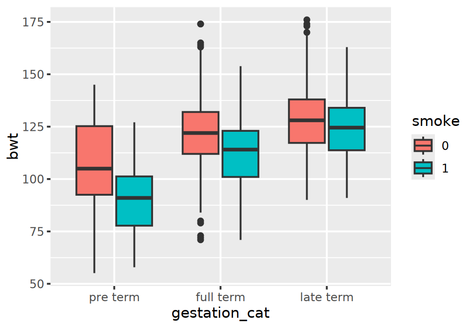

```r
ggplot(bw_data, aes(x=gestation_cat, fill=smoke, y=bwt)) +
  geom_boxplot()
```

It appears that the effect of smoking is strongest for earlier term pregnancies. The significance of the dependence of smoking effect on pregnancy term is captured in the interaction term of the model.

### 2.4.6 **TAKE HOME:** Additional examples with t-test and ANOVA

**Check normality: Shapiro test**

**Caution**: a large sample size will usually result in a significant p-value from Shapiro test, because any tiny deviation from normality will be detected. We should also look at how far `W` is from 1 to see how big the deviation is. For reasonably small differences, the normality assumption is probably still OK.

1. First we will get a sense of the number of replicates (n) and plot a histogram

```r
length(bw_data$bwt)
```

```
## [1] 1174
```

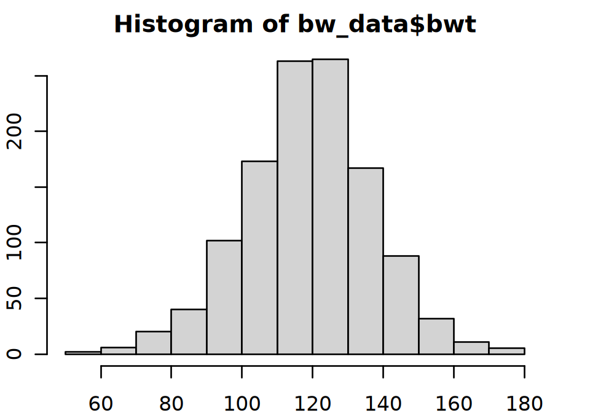

```r
hist(bw_data$bwt)
```

2. Run the Shapiro test. Look at the value of `W` and `p`

```r
shapiro.test(bw_data$bwt)
```

```
##
##  Shapiro-Wilk normality test
##
## data:  bw_data$bwt
## W = 0.99563, p-value = 0.001917
```

3. Use QQ-normal plot (`qqnorm()`) to check the normality.
- If the data is normally distributed, the points in the QQ-normal plot will lie on a straight diagonal line.
- The `qqline()` function will show the line for a “theoretical” normal distribution

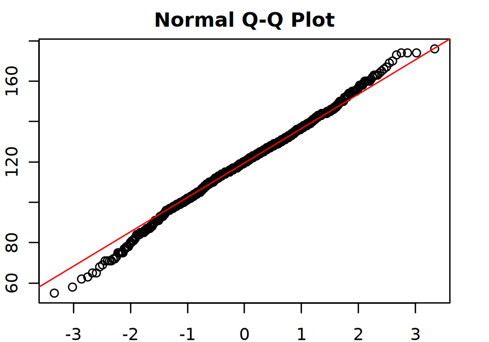

```r
qqnorm(bw_data$bwt)
qqline(bw_data$bwt, col="red")
```

**Alternative data** - run test on raw counts from RNA-seq

1. Get raw sequence data

```r
raw.count <- read.delim("http://wd.cri.uic.edu/advanced_R/raw.count.txt",row.names=1)
```

2. Convert to the first gene’s raw read count to a numeric vector

```r
count <- as.numeric(raw.count[1, ])
```

3. Check the number of samples and plot a histogram

```r
length(count)
```

```
## [1] 46
```

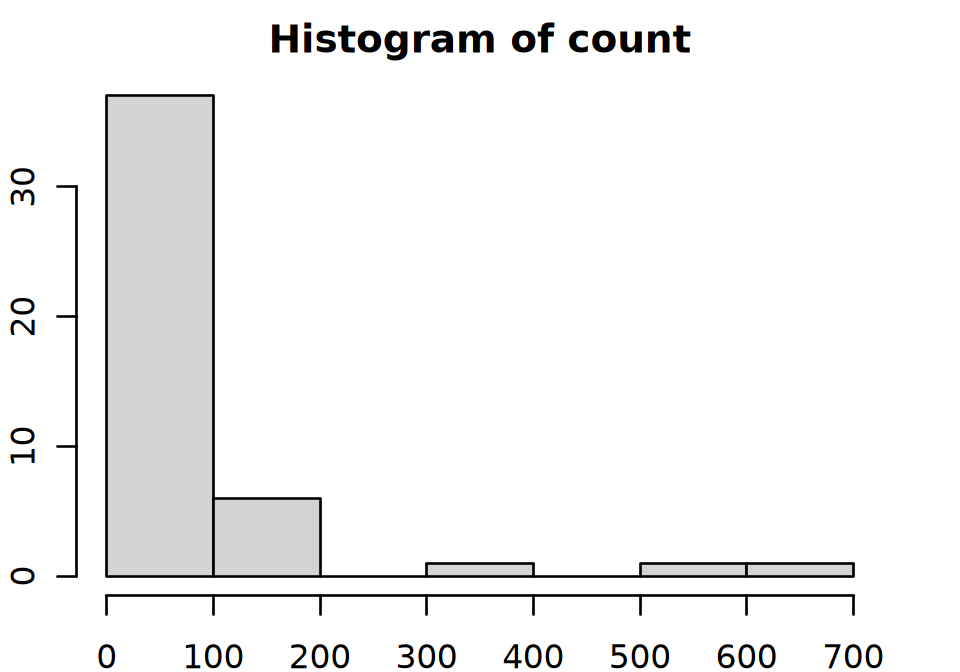

```r
hist(count)
```

4. Run the Shaprio test

```r
shapiro.test(count)
```

```
##
##  Shapiro-Wilk normality test
##
## data:  count
## W = 0.49027, p-value = 2.014e-11
```

5. Create the Q-Q plot

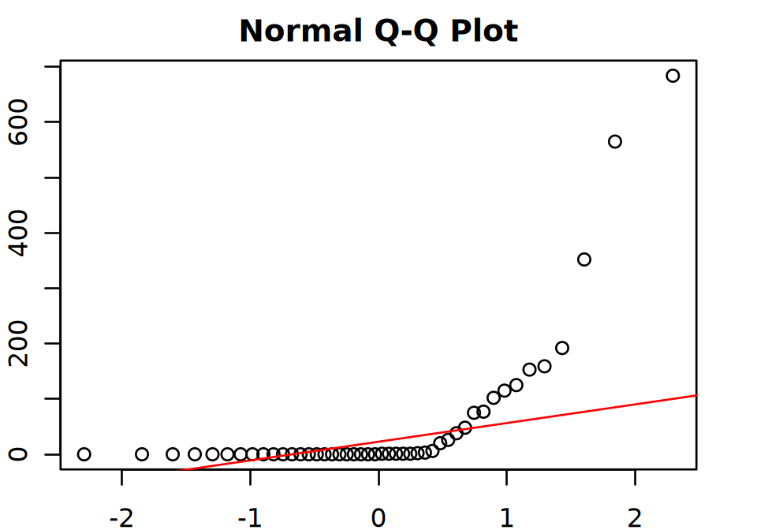

```r
qqnorm(count)
qqline(count, col="red")
```

Birth weight values are *close* to normal. The RNA-seq values are *not* close to normal.

**T-test boxplot:** Add the p-values from the tests to the plot.

- We will use the `signif()` function to round to 3 significant figures.

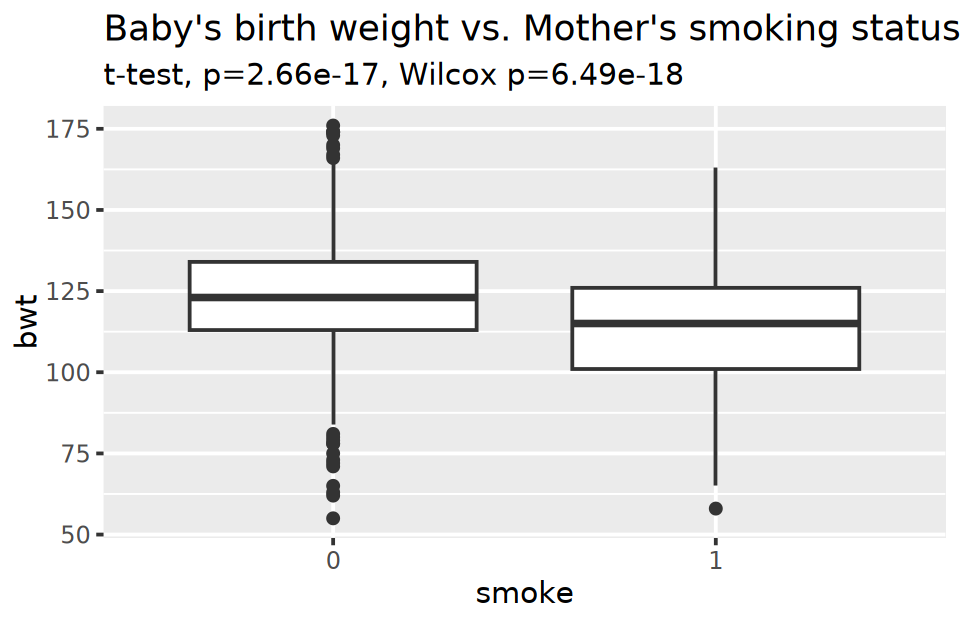

```r
# save the wilcox test object
wilcox_result <- wilcox.test(bwt ~ smoke, data=bw_data)
# plot with a subtitle
ggplot(bw_data, aes(x=smoke, y=bwt)) +
  geom_boxplot() +
  labs(title="Baby's birth weight vs. Mother's smoking status",
       subtitle=paste0("t-test, p=", signif(ttest_result$p.value, 3),
                       ", Wilcox p=", signif(wilcox_result$p.value, 3)))
```

## 2.5 Correlation and linear regression

### 2.5.1 Correlation

Comparison of mother’s height and weight.

1. Perform correlation test using Pearson’s test

```r
cor.test(bw_data$height, bw_data$weight)
```

```
##
##  Pearson's product-moment correlation
##
## data:  bw_data$height and bw_data$weight
## t = 16.552, df = 1172, p-value < 2.2e-16
## alternative hypothesis: true correlation is not equal to 0
## 95 percent confidence interval:
##  0.3877305 0.4805332
## sample estimates:
##       cor
## 0.4352874
```

2. Using Spearman’s test

```r
cor.test(bw_data$height, bw_data$weight, method="spearman")
```

```
##
##  Spearman's rank correlation rho
##
## data:  bw_data$height and bw_data$weight
## S = 134713533, p-value < 2.2e-16
## alternative hypothesis: true rho is not equal to 0
## sample estimates:
##       rho
## 0.5004735
```

3. Using Kendall’s Tau test

```r
cor.test(bw_data$height, bw_data$weight, method="kendall")
```

```
##
##  Kendall's rank correlation tau
##
## data:  bw_data$height and bw_data$weight
## z = 18.02, p-value < 2.2e-16
## alternative hypothesis: true tau is not equal to 0
## sample estimates:
##       tau
## 0.3743995
```

4. Generate scatter plot

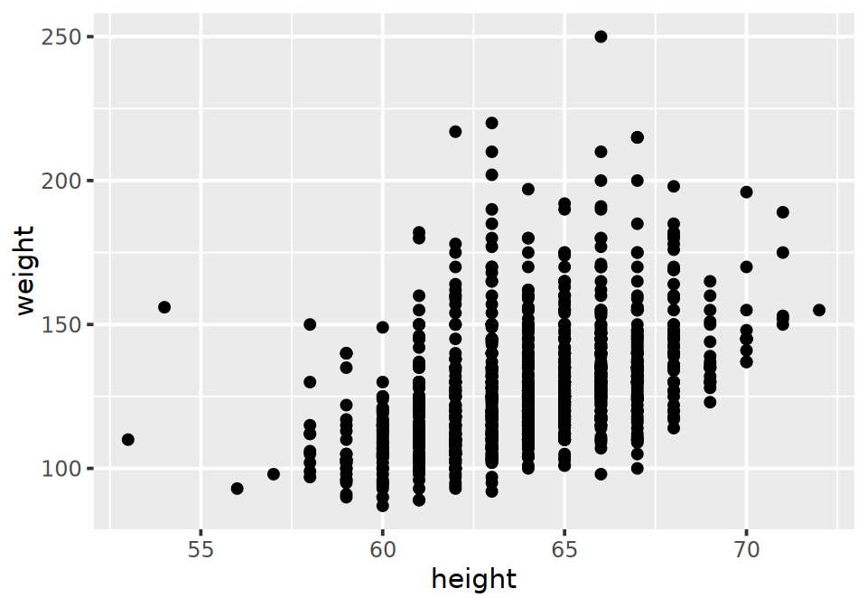

```r
ggplot(bw_data, aes(x=height, y=weight)) +
  geom_point()
```

### 2.5.2 Linear regression

This time compare birth weight to gestation (comparison already done as categorized gestation) and other variables.

1. Perform simple linear regression

```r
summary(lm(bwt ~ gestation, data=bw_data))
```

```
##
## Call:
## lm(formula = bwt ~ gestation, data = bw_data)
##
## Residuals:
##     Min      1Q  Median      3Q     Max
## -49.348 -11.065   0.218  10.101  57.704
##
## Coefficients:
##              Estimate Std. Error t value Pr(>|t|)
## (Intercept) -10.75414    8.53693   -1.26    0.208
## gestation     0.46656    0.03054   15.28   <2e-16 ***
## ---
## Signif. codes:  0 '***' 0.001 '**' 0.01 '*' 0.05 '.' 0.1 ' ' 1
##
## Residual standard error: 16.74 on 1172 degrees of freedom
## Multiple R-squared:  0.1661, Adjusted R-squared:  0.1654
## F-statistic: 233.4 on 1 and 1172 DF,  p-value: < 2.2e-16
```

2. Generate scatter plot

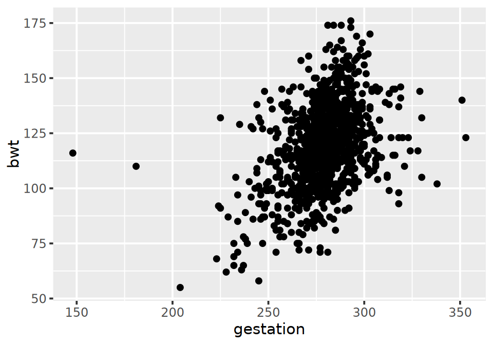

```r
ggplot(bw_data, aes(x=gestation, y=bwt)) +
  geom_point()
```

3. Add best-fit line to scatter plot.
   - `se=T` will add standard error bars

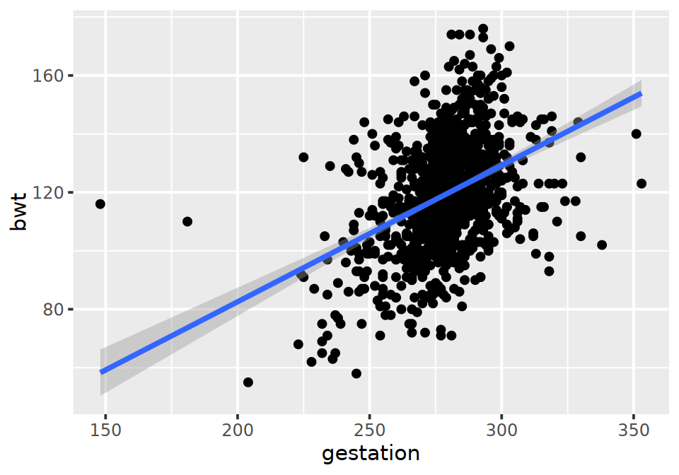

```r
ggplot(bw_data, aes(x=gestation, y=bwt)) +
  geom_point() +
  geom_smooth(method="lm", se=T)
```

### 2.5.3 **TAKE HOME:** Multiple regression

Additive model

```r
summary(lm(bwt ~ gestation + smoke + weight, data=bw_data))
```

```
##
## Call:
## lm(formula = bwt ~ gestation + smoke + weight, data = bw_data)
##
## Residuals:
##     Min      1Q  Median      3Q     Max
## -51.920 -10.759  -0.279   9.743  51.354
##
## Coefficients:
##              Estimate Std. Error t value Pr(>|t|)
## (Intercept) -17.62648    8.69128  -2.028   0.0428 *
## gestation     0.44809    0.02936  15.261  < 2e-16 ***
## smoke1       -8.07789    0.96444  -8.376  < 2e-16 ***
## weight        0.11818    0.02267   5.213  2.2e-07 ***
## ---
## Signif. codes:  0 '***' 0.001 '**' 0.01 '*' 0.05 '.' 0.1 ' ' 1
##
## Residual standard error: 16.07 on 1170 degrees of freedom
## Multiple R-squared:  0.2335, Adjusted R-squared:  0.2315
## F-statistic: 118.8 on 3 and 1170 DF,  p-value: < 2.2e-16
```

Using the full model with all interactions

```r
summary(lm(bwt ~ gestation * smoke * weight, data=bw_data))
```

```
##
## Call:
## lm(formula = bwt ~ gestation * smoke * weight, data = bw_data)
##
## Residuals:
##     Min      1Q  Median      3Q     Max
## -51.657 -10.597  -0.062   9.738  47.653
##
## Coefficients:
##                           Estimate Std. Error t value Pr(>|t|)
## (Intercept)             -1.118e+02  7.032e+01  -1.590  0.11208
## gestation                7.857e-01  2.514e-01   3.125  0.00182 **
## smoke1                   2.711e+01  1.093e+02   0.248  0.80409
## weight                   9.945e-01  5.297e-01   1.877  0.06070 .
## gestation:smoke1        -1.197e-01  3.912e-01  -0.306  0.75965
## gestation:weight        -3.140e-03  1.895e-03  -1.657  0.09777 .
## smoke1:weight           -7.161e-01  8.342e-01  -0.858  0.39082
## gestation:smoke1:weight  2.520e-03  2.984e-03   0.845  0.39848
## ---
## Signif. codes:  0 '***' 0.001 '**' 0.01 '*' 0.05 '.' 0.1 ' ' 1
##
## Residual standard error: 15.99 on 1166 degrees of freedom
## Multiple R-squared:  0.2431, Adjusted R-squared:  0.2386
## F-statistic: 53.51 on 7 and 1166 DF,  p-value: < 2.2e-16
```

The overall explained variance is about the same. With more terms in the full model the explanatory value of each variable is lower. We will test the *effect* of each variable using ANOVA.

```r
summary(aov(bwt ~ gestation * smoke * weight, data=bw_data))
```

```
##                          Df Sum Sq Mean Sq F value   Pr(>F)
## gestation                 1  65450   65450 255.871  < 2e-16 ***
## smoke                     1  19533   19533  76.365  < 2e-16 ***
## weight                    1   7015    7015  27.425 1.94e-07 ***
## gestation:smoke           1   3069    3069  11.997 0.000552 ***
## gestation:weight          1    538     538   2.104 0.147137
## smoke:weight              1     18      18   0.072 0.788345
## gestation:smoke:weight    1    182     182   0.713 0.398481
## Residuals              1166 298252     256
## ---
## Signif. codes:  0 '***' 0.001 '**' 0.01 '*' 0.05 '.' 0.1 ' ' 1
```

5. Generate different plots for comparison of variables
   - *Birth weight vs gestation and smoking:*

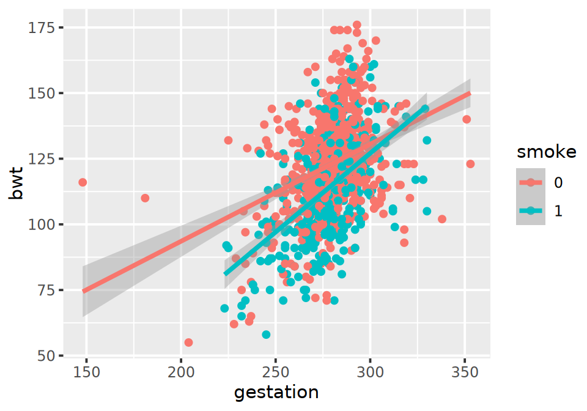

```r
ggplot(bw_data, aes(x=gestation, y=bwt, color=smoke)) +
  geom_point() +
  geom_smooth(method="lm", se=T)
```

In the statistics we see significant effects for each variable *and* their interaction. Observe that the best-fit line’s slope (bwt vs gestation) changes for different smoking status, which reflects the interaction.

[output not shown]

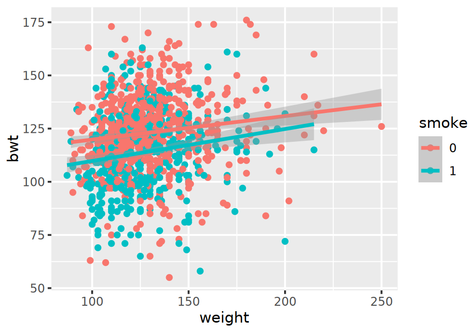

```r
ggplot(bw_data, aes(x=weight, y=bwt, color=smoke)) +
  geom_point() +
  geom_smooth(method="lm", se=T)
```

In the statistics we see signficant effects for each variable, but no interaction. Correspondingly, we see about the same slope in the best-fit line regardless of smoking status.

## 2.6 Fisher’s Exact and Chi-squared tests

### 2.6.1 Fisher’s Exact test

Test for an association of smoking and parity.

1. Make sure both are factors. For this example, we will use the `mutate()` function from the dplyr package to do in one command.

```r
bw_data <- bw_data %>%
  mutate(smoke=factor(smoke),
         parity=factor(parity))
```

2. Will take a peek at the data and then use the `table()` function to generate the contingency table.

```r
head(bw_data[, c("smoke","parity")])
```

|  | smoke | parity |
| --- | --- | --- |
| 1 | 0 | 0 |
| 2 | 0 | 0 |
| 3 | 1 | 0 |
| 4 | 1 | 0 |
| 5 | 0 | 0 |
| 6 | 0 | 0 |

```r
smoke_vs_parity_table <- table(bw_data[, c("smoke", "parity")])
smoke_vs_parity_table
```

```
##      parity
## smoke   0   1
##     0 525 190
##     1 341 118
```

3. Run Fisher’s Exact test. First we will run to see the report and then save to a variable

```r
fisher.test(smoke_vs_parity_table)
```

```
##
##  Fisher's Exact Test for Count Data
##
## data:  smoke_vs_parity_table
## p-value = 0.7857
## alternative hypothesis: true odds ratio is not equal to 1
## 95 percent confidence interval:
##  0.7245511 1.2590005
## sample estimates:
## odds ratio
##  0.9561918
```

```r
fet <- fisher.test(smoke_vs_parity_table)
```

4. Compute the log2 odd’s ratio

```r
log2(fet$estimate)
```

```
## odds ratio
## -0.0646281
```

5. Generate visualizations.
- First plot the total counts.
- Then plot the proportions. This is what we are testing.

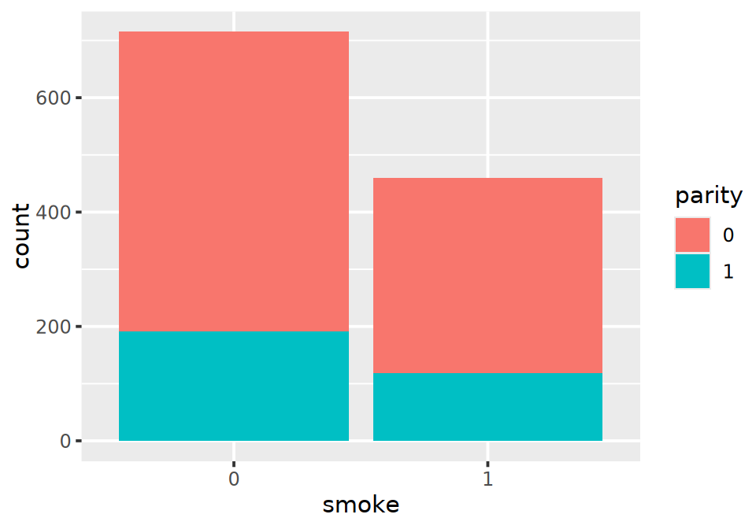

```r
ggplot(bw_data, aes(x=smoke, fill=parity)) +
  geom_bar()
```

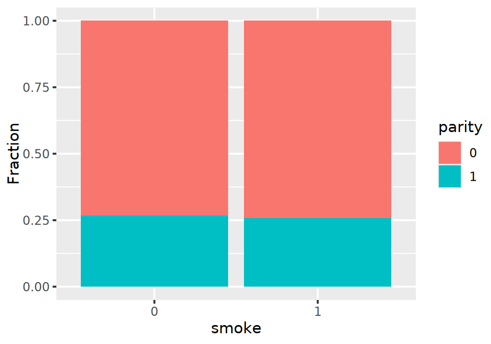

```r
ggplot(bw_data, aes(x=smoke, fill=parity)) +
  geom_bar(position="fill") +
  labs(y="Fraction")
```

No effect observed in this case.

### 2.6.2 **TAKE HOME:** Chi-square test

Test for association of smoking and gestation category

**If you had not done so before**, run the categorization

```r
bw_data <- bw_data %>%
  mutate(gestation_cat=cut(gestation,
                             breaks=c(0, 37*7, 41*7, Inf),
                             labels=c("pre term", "full term", "late term"),
                             right=F))
```

1. Run the Chi-square test
   - Like Fisher’s exact test, first we will create a contigency table.
   - Then run `chisq.test()` on the contigency table

```r
smoke_vs_gest_table <- table(bw_data[,c("smoke","gestation_cat")])
chisq.test(smoke_vs_gest_table)
```

```
##
##  Pearson's Chi-squared test
##
## data:  smoke_vs_gest_table
## X-squared = 9.8147, df = 2, p-value = 0.007392
```

2. Generate a visualization.

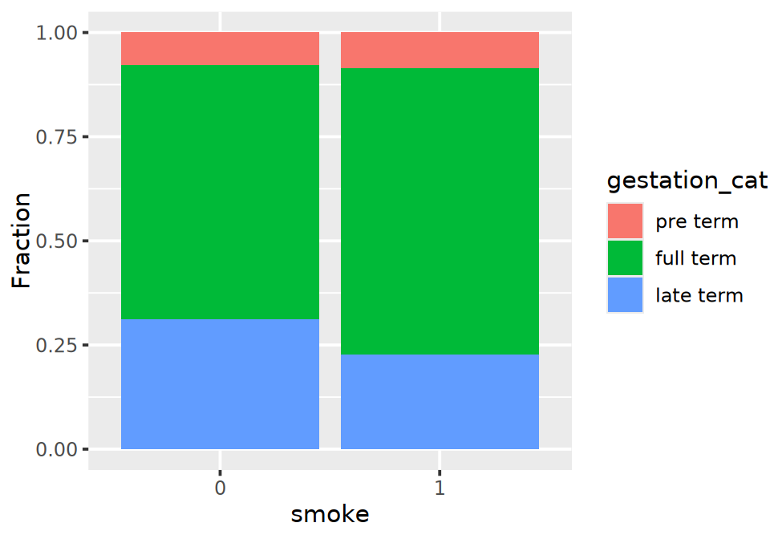

```r
ggplot(bw_data, aes(x=smoke, fill=gestation_cat)) +
  geom_bar(position="fill") +
  labs(y="Fraction")
```

**Alternative visualization: Mosaic plot**

Use the `vcd` (Visualization of Categorical Data) package. Install the package if you have not already.

1. If you have not done so already, install the `vcd` package

```r
install.packages("vcd")
```

The `mosaic()` function is built on base R plots. We can provide it directly with the contingency table. The shading options will shade based on over- or under-representation of each group based on the residuals from the Chi-square test.

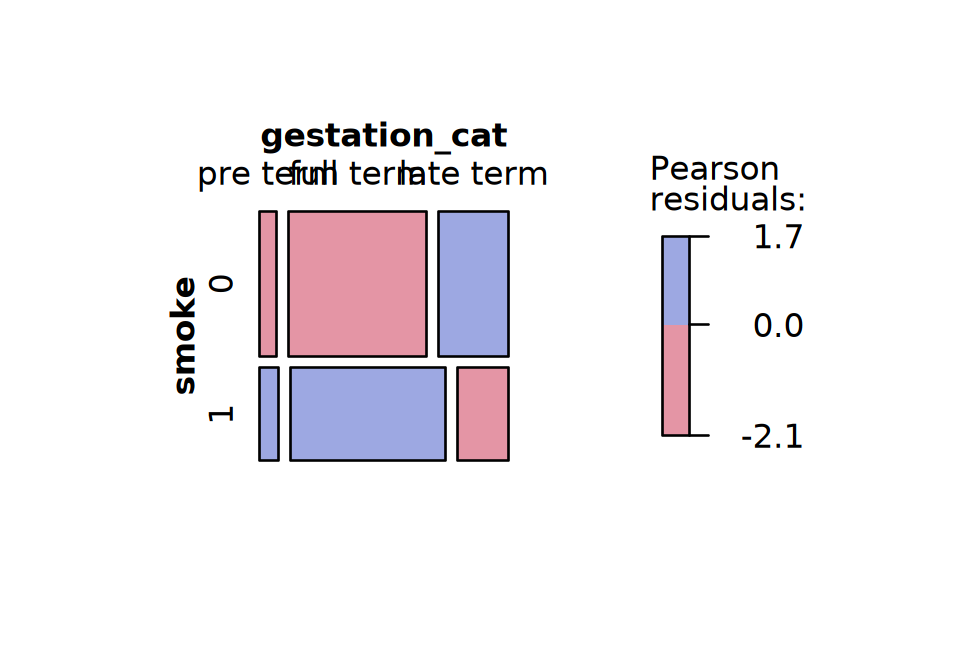

```r
library(vcd)
mosaic(smoke_vs_gest_table, shade=T, legend=T, gp=shading_binary)
```

**Post-hoc for Chi-square test using Fisher’s Exact**

We have a significant difference from Chi-square. Which groups show the differences? Visually it looks like the full term and late term groups have different proportions of smokers.

Test for individual differences with Fisher’s Exact test.

```r
# store groups to run tests over
cols <- ncol(smoke_vs_gest_table)
# start an empty data frame
term_stats <- data.frame()
# run a test for each column (term group) one at a time
for(i in 1:cols){
  # get the counts for this term group
  term.counts <- smoke_vs_gest_table[,i]
  # get the counts for all other term groups
  term.other <- rowSums(smoke_vs_gest_table[,-i])
  # we're specifically seeing if THIS term group has a different distribution
  # of smoking vs non-smoking mothers, using fisher's exact test
  term.table <- cbind(term.counts, term.other)
  fet <- fisher.test(term.table)
  # combine the estimate (odds ratio) and p-value) into the data frame
  # and use the term group as the row name
  term_stats <- rbind(term_stats, c(fet$estimate, fet$p.value) )
  rownames(term_stats)[nrow(term_stats)] <- colnames(smoke_vs_gest_table)[i]
}
# set the column names, and add log2-scaled odds ratio and FDR corrected p-value
colnames(term_stats) <- c("OddsRatio","P.Value")
term_stats$Log2OddsRatio <- log2(term_stats$OddsRatio)
term_stats$Q.Value <- p.adjust(term_stats$P.Value,method="fdr")
term_stats
```

|  | OddsRatio | P.Value | Log2OddsRatio | Q.Value |
| --- | --- | --- | --- | --- |
| pre term | 0.8902280 | 0.587238941 | -0.1677532 | 0.587238941 |
| full term | 0.7188088 | 0.008928847 | -0.4763200 | 0.013393270 |
| late term | 1.5365329 | 0.001703438 | 0.6196786 | 0.005110315 |

We see statistically significant differences in mother smoking frequency for full term and late term.

We will discuss the FDR correction (used above) next.